# MidtermCOMPSCIX 415.2 Homework 5/Midterm

Sharmistha Maitra

3/1/2018

# **Git and Github (1.5 points)**

## link to Git repository

[link](https://github.com/sharmisthamaitra/compscix-415-2-assignments)

```r
library(nycflights13)
library(tidyverse)
library(dplyr)
```

# RStudio and R Markdown (3 points)

```r
##1.Use markdown headers in your document to clearly separate each midterm question and add a table of contents to your document.
```

# **The tidyverse packages (3 points)**

## 1.Can you name which package is associated with each task below?

```r
#Plotting - package tidyverse, Core member 1) ggplot2 needed.


#Data munging/wrangling - package tidyverse, Core members 1) tidyr 2) Tibble 3) dlpyr needed.


#Reshaping (speading and gathering) - package tidyverse, Core members 1) tidyr needed.


#Importing/exporting data - package tidyverse, Core members 1) readr needed.
```

## 2.Now can you name two functions that you’ve used from each package that you listed above for these tasks?

```r
#Plotting - ggplot(), geom_point() for ggplot2 package.

#Data munging/wrangling -tibble(),filter(), arrange(), select(), summarise()

#Reshaping data - gather(), spread() for tidyr package

#Importing/exporting data  - read_csv, read_tsv, write_csv, readRDS, saveRDS for readr package
```

# **R Basics (1.5 points)**

## 1. Fix this code with the fewest number of changes possible so it works:

```r
#My_data.name___is.too00ooLong! <- c( 1 , 2   , 3 )

My_data.name___is.too00ooLong <- c( 1 , 2   , 3 )
My_data.name___is.too00ooLong
```

```
## [1] 1 2 3
```

## 2.Fix this code so it works:

```r
#my_string <- C('has', 'an', 'error', 'in', 'it)

my_string <- c('has', 'an', 'error', 'in', 'it')
my_string
```

```
## [1] "has"   "an"    "error" "in"    "it"
```

## 3.Look at the code below and comment on what happened to the values in the vector.

```r
#The integer values 1 and 2 got converted into character vectors

my_vector <- c(1, 2, '3', '4', 5)
my_vector
```

```
## [1] "1" "2" "3" "4" "5"
```

# **Data import/export (3 points)**

## 1.Download the rail_trail.txt file from Canvas (in the Midterm Exam section here) and successfully import it into R. Prove that it was imported successfully by including your import code and taking a glimpse of the result.

```r
railtrail_file_path <- "/Users/sharmisthamaitra/compscix-415-2-assignments/rail_trail.txt"
rail_data <- read.table(railtrail_file_path,
               header = TRUE,
               sep="|"
               )
glimpse(rail_data)
```

```
## Observations: 90
## Variables: 10
## $ hightemp   <int> 83, 73, 74, 95, 44, 69, 66, 66, 80, 79, 78, 65, 41,...
## $ lowtemp    <int> 50, 49, 52, 61, 52, 54, 39, 38, 55, 45, 55, 48, 49,...
## $ avgtemp    <dbl> 66.5, 61.0, 63.0, 78.0, 48.0, 61.5, 52.5, 52.0, 67....
## $ spring     <int> 0, 0, 1, 0, 1, 1, 1, 1, 0, 0, 0, 1, 1, 0, 0, 1, 0, ...
## $ summer     <int> 1, 1, 0, 1, 0, 0, 0, 0, 1, 1, 1, 0, 0, 0, 0, 0, 1, ...
## $ fall       <int> 0, 0, 0, 0, 0, 0, 0, 0, 0, 0, 0, 0, 0, 1, 1, 0, 0, ...
## $ cloudcover <dbl> 7.6, 6.3, 7.5, 2.6, 10.0, 6.6, 2.4, 0.0, 3.8, 4.1, ...
## $ precip     <dbl> 0.00, 0.29, 0.32, 0.00, 0.14, 0.02, 0.00, 0.00, 0.0...
## $ volume     <int> 501, 419, 397, 385, 200, 375, 417, 629, 533, 547, 4...
## $ weekday    <int> 1, 1, 1, 0, 1, 1, 1, 0, 0, 1, 1, 1, 1, 1, 1, 1, 0, ...
```

## 2.Export the file into an R-specific format and name it “rail_trail.rds”. Make sure you define the path correctly so that you know where it gets saved. Then reload the file. Include your export and import code and take another glimpse.

```r
saveRDS(rail_data, "/Users/sharmisthamaitra/compscix-415-2-assignments/rail_trail.rds")


railtrail_file_path_rds <- "/Users/sharmisthamaitra/compscix-415-2-assignments/rail_trail.rds"

rail_data_rds <- readRDS(railtrail_file_path_rds)
glimpse(rail_data_rds)
```

```
## Observations: 90
## Variables: 10
## $ hightemp   <int> 83, 73, 74, 95, 44, 69, 66, 66, 80, 79, 78, 65, 41,...
## $ lowtemp    <int> 50, 49, 52, 61, 52, 54, 39, 38, 55, 45, 55, 48, 49,...
## $ avgtemp    <dbl> 66.5, 61.0, 63.0, 78.0, 48.0, 61.5, 52.5, 52.0, 67....
## $ spring     <int> 0, 0, 1, 0, 1, 1, 1, 1, 0, 0, 0, 1, 1, 0, 0, 1, 0, ...
## $ summer     <int> 1, 1, 0, 1, 0, 0, 0, 0, 1, 1, 1, 0, 0, 0, 0, 0, 1, ...
## $ fall       <int> 0, 0, 0, 0, 0, 0, 0, 0, 0, 0, 0, 0, 0, 1, 1, 0, 0, ...
## $ cloudcover <dbl> 7.6, 6.3, 7.5, 2.6, 10.0, 6.6, 2.4, 0.0, 3.8, 4.1, ...
## $ precip     <dbl> 0.00, 0.29, 0.32, 0.00, 0.14, 0.02, 0.00, 0.00, 0.0...
## $ volume     <int> 501, 419, 397, 385, 200, 375, 417, 629, 533, 547, 4...
## $ weekday    <int> 1, 1, 1, 0, 1, 1, 1, 0, 0, 1, 1, 1, 1, 1, 1, 1, 0, ...
```

# **Visualization (6 points).**

## 1.Critique this graphic: give only three examples of what is wrong with this graphic. Be concise.

```r
#The size of the circles is not proportional to the percentages they represent. For example 79 is a huge circle while 16 is very tiny.

#Dont know what the black circles represent, if they are percentages of women or men

#For graphs showing percentage comparisons, I would expect YES and NO  percentages to add up to 100, but that is not happening anywhere in this graph.
```

[output not shown]

## 2.Reproduce this graphic using the diamonds data set.

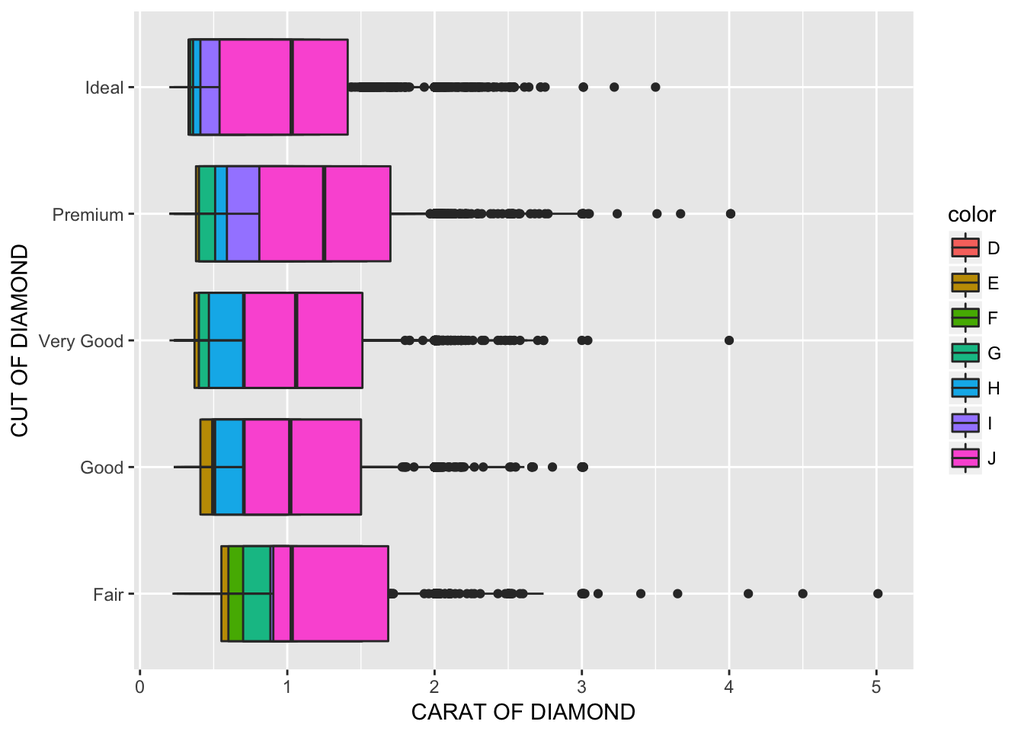

```r
ggplot(data = diamonds, mapping = aes(x = cut, y = carat, fill = color) )+
geom_boxplot(position = "identity") +
labs(x = "CUT OF DIAMOND", y = "CARAT OF DIAMOND") +
coord_flip()
```

## 3.The previous graphic is not very useful. We can make it much more useful by changing one thing about it. Make the change and plot it again.

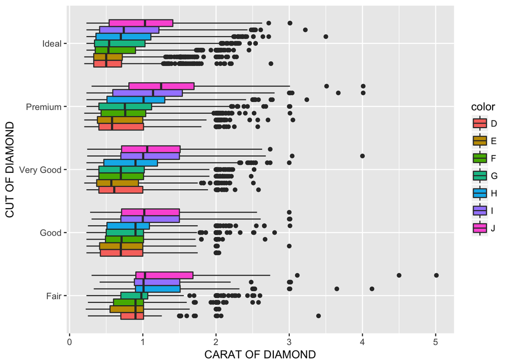

```r
#The previous graphic is not very helpful because within each boxplot(drawn for each cut) it stacks boxplots for each color making the graphic difficult to understand. So I changed to 'position = "dodge" inside geom_boxplot() , the resultant graphic has a separate box plot for each color diamond, for each cut.

ggplot(data = diamonds, mapping = aes(x = cut, y = carat, fill = color)) +
 geom_boxplot(position = "dodge") +
labs(x = "CUT OF DIAMOND", y = "CARAT OF DIAMOND") +
  coord_flip()
```

# **Data munging and wrangling (6 points)**

## 1.Is this data “tidy”? If yes, leave it alone and go to the next problem. If no, make it tidy. Note: this data set is called table2 and is available in the tidyverse package. It should be ready for you to use after you’ve loaded the tidyverse package.

```r
#This data is not tidy because
#There are 3 rules which make a dataset tidy:
#Each variable must have its own column.
#Each observation must have its own row.
#Each value must have its own cell.
#Here we see  two different variables "cases" and "population" have been listed under one column 'type', the variables need to be spread out into two separate columns with the spread() function.


#tibble_table2 <- as_tibble(table2)
#tibble_table2

spread(table2, key = type, value = count)
```

```
## # A tibble: 6 x 4
##       country  year  cases population
## *       <chr> <int>  <int>      <int>
## 1 Afghanistan  1999    745   19987071
## 2 Afghanistan  2000   2666   20595360
## 3      Brazil  1999  37737  172006362
## 4      Brazil  2000  80488  174504898
## 5       China  1999 212258 1272915272
## 6       China  2000 213766 1280428583
```

## 2.Create a new column in the diamonds data set called price_per_carat that shows the price of each diamond per carat (hint: divide). Only show me the code, not the output.

```r
mutate(diamonds, price_per_carat = price/carat)
```

```
## # A tibble: 53,940 x 11
##    carat       cut color clarity depth table price     x     y     z
##    <dbl>     <ord> <ord>   <ord> <dbl> <dbl> <int> <dbl> <dbl> <dbl>
##  1  0.23     Ideal     E     SI2  61.5    55   326  3.95  3.98  2.43
##  2  0.21   Premium     E     SI1  59.8    61   326  3.89  3.84  2.31
##  3  0.23      Good     E     VS1  56.9    65   327  4.05  4.07  2.31
##  4  0.29   Premium     I     VS2  62.4    58   334  4.20  4.23  2.63
##  5  0.31      Good     J     SI2  63.3    58   335  4.34  4.35  2.75
##  6  0.24 Very Good     J    VVS2  62.8    57   336  3.94  3.96  2.48
##  7  0.24 Very Good     I    VVS1  62.3    57   336  3.95  3.98  2.47
##  8  0.26 Very Good     H     SI1  61.9    55   337  4.07  4.11  2.53
##  9  0.22      Fair     E     VS2  65.1    61   337  3.87  3.78  2.49
## 10  0.23 Very Good     H     VS1  59.4    61   338  4.00  4.05  2.39
## # ... with 53,930 more rows, and 1 more variables: price_per_carat <dbl>
```

## 3.For each cut of diamond in the diamonds data set, how many diamonds, and what proportion, have a price > 10000 and a carat < 1.5? There are several ways to get to an answer, but your solution must use the data wrangling verbs from the tidyverse in order to get credit.

### Do the results make sense? Why?

### Do we need to be wary of any of these numbers? Why?

```r
#From the result table below, there are more diamonds with price>10000 and carat <1.5 for the Ideal cut. The general trend of is as the cut of the diamonds improves from fair to ideal, there are more diamonds that fall in the above range.


diamonds_per_cut <- diamonds %>%
                      group_by(cut) %>%
                      arrange(cut) %>%
                      summarize(
                        diamonds = sum(n())
                        )
#diamonds_per_cut



selected_diamonds_per_cut <- diamonds %>%
                            filter(price > 10000, carat < 1.5 ) %>%
                            group_by(cut) %>%
                            arrange(cut) %>%
                           summarize(
                                 selected_diamonds = sum(n())
                             )
#selected_diamonds_per_cut


#Now joining the two diamonds tables above, key is 'cut' of diamonds.
#x %>%
#  inner_join(y, by = "key")
diamonds_table_join <- diamonds_per_cut %>%
                       inner_join(selected_diamonds_per_cut, by = "cut")
#diamonds_table_join



proportion_diamonds_pricegt10000_carat_lt1.5 <- diamonds_table_join %>%
                                                group_by(cut) %>%
                                               summarise(
                                                        diamonds,
                                                        selected_diamonds,
                                                        proportion = selected_diamonds/diamonds
                                                )
proportion_diamonds_pricegt10000_carat_lt1.5
```

```
## # A tibble: 5 x 4
##         cut diamonds selected_diamonds  proportion
##       <ord>    <int>             <int>       <dbl>
## 1      Fair     1610                 4 0.002484472
## 2      Good     4906                17 0.003465145
## 3 Very Good    12082               155 0.012829002
## 4   Premium    13791               173 0.012544413
## 5     Ideal    21551               485 0.022504756
```

# **EDA (6 points) for txhousing dataset**

## 1.During what time period is this data from?

```r
#The time frame for txhousing dataframe is from year January 2000 to July 2015, with data present for all consecutive months in between.

glimpse(txhousing)
```

```
## Observations: 8,602
## Variables: 9
## $ city      <chr> "Abilene", "Abilene", "Abilene", "Abilene", "Abilene...
## $ year      <int> 2000, 2000, 2000, 2000, 2000, 2000, 2000, 2000, 2000...
## $ month     <int> 1, 2, 3, 4, 5, 6, 7, 8, 9, 10, 11, 12, 1, 2, 3, 4, 5...
## $ sales     <dbl> 72, 98, 130, 98, 141, 156, 152, 131, 104, 101, 100, ...
## $ volume    <dbl> 5380000, 6505000, 9285000, 9730000, 10590000, 139100...
## $ median    <dbl> 71400, 58700, 58100, 68600, 67300, 66900, 73500, 750...
## $ listings  <dbl> 701, 746, 784, 785, 794, 780, 742, 765, 771, 764, 72...
## $ inventory <dbl> 6.3, 6.6, 6.8, 6.9, 6.8, 6.6, 6.2, 6.4, 6.5, 6.6, 6....
## $ date      <dbl> 2000.000, 2000.083, 2000.167, 2000.250, 2000.333, 20...
```

```r
tx_housing_tibble <- as_tibble(txhousing)
tx_housing_tibble
```

```
## # A tibble: 8,602 x 9
##       city  year month sales   volume median listings inventory     date
##      <chr> <int> <int> <dbl>    <dbl>  <dbl>    <dbl>     <dbl>    <dbl>
##  1 Abilene  2000     1    72  5380000  71400      701       6.3 2000.000
##  2 Abilene  2000     2    98  6505000  58700      746       6.6 2000.083
##  3 Abilene  2000     3   130  9285000  58100      784       6.8 2000.167
##  4 Abilene  2000     4    98  9730000  68600      785       6.9 2000.250
##  5 Abilene  2000     5   141 10590000  67300      794       6.8 2000.333
##  6 Abilene  2000     6   156 13910000  66900      780       6.6 2000.417
##  7 Abilene  2000     7   152 12635000  73500      742       6.2 2000.500
##  8 Abilene  2000     8   131 10710000  75000      765       6.4 2000.583
##  9 Abilene  2000     9   104  7615000  64500      771       6.5 2000.667
## 10 Abilene  2000    10   101  7040000  59300      764       6.6 2000.750
## # ... with 8,592 more rows
```

```r
time_frame_txhousing <- txhousing %>% select(year, month) %>% arrange() %>% unique()

time_frame_txhousing
```

```
## # A tibble: 187 x 2
##     year month
##    <int> <int>
##  1  2000     1
##  2  2000     2
##  3  2000     3
##  4  2000     4
##  5  2000     5
##  6  2000     6
##  7  2000     7
##  8  2000     8
##  9  2000     9
## 10  2000    10
## # ... with 177 more rows
```

## 2.How many cities are represented?

```r
#46 cities are represented. The list of cities shown in the output below.

cities <- txhousing %>% select(city) %>% unique()
cities
```

```
## # A tibble: 46 x 1
##                     city
##                    <chr>
##  1               Abilene
##  2              Amarillo
##  3             Arlington
##  4                Austin
##  5              Bay Area
##  6              Beaumont
##  7       Brazoria County
##  8           Brownsville
##  9 Bryan-College Station
## 10         Collin County
## # ... with 36 more rows
```

```r
count_cities <- cities %>% count()
count_cities
```

```
## # A tibble: 1 x 1
##       n
##   <int>
## 1    46
```

## 3.Which city, month and year had the highest number of sales?

```r
#City of Houston , in month of July in year 2015 had the highest sale of 8945 properties.
txhousing_sales_desc <- txhousing %>%
                           arrange(desc(sales))
txhousing_sales_desc
```

```
## # A tibble: 8,602 x 9
##       city  year month sales     volume median listings inventory     date
##      <chr> <int> <int> <dbl>      <dbl>  <dbl>    <dbl>     <dbl>    <dbl>
##  1 Houston  2015     7  8945 2568156780 217600    23875       3.4 2015.500
##  2 Houston  2006     6  8628 1795898108 155200    36281       5.6 2006.417
##  3 Houston  2013     7  8468 2168720825 187800    21497       3.3 2013.500
##  4 Houston  2015     6  8449 2490238594 222400    22311       3.2 2015.417
##  5 Houston  2013     5  8439 2121508529 186100    20526       3.3 2013.333
##  6 Houston  2014     6  8391 2342443127 211200    19725       2.9 2014.417
##  7 Houston  2014     7  8391 2278932511 199700    20214       3.0 2014.500
##  8 Houston  2014     8  8167 2195184825 202400    20007       2.9 2014.583
##  9 Houston  2013     8  8155 2083377894 186700    21366       3.3 2013.583
## 10 Houston  2006     5  8040 1602621368 151200    35398       5.5 2006.333
## # ... with 8,592 more rows
```

```r
City_with_highest_sale <- txhousing_sales_desc %>%
                          head(1) %>%
                          transmute(city, month, year, sales)

City_with_highest_sale
```

```
## # A tibble: 1 x 4
##      city month  year sales
##     <chr> <int> <int> <dbl>
## 1 Houston     7  2015  8945
```

## 4.What kind of relationship do you think exists between the number of listings and the number of sales? Check your assumption and show your work.

```r
#The number of sales is directly related to the number of listings. An increase in the number of listings means increase in the number of sales. Below plot of sales vs listings illustrate that.

txhousing_listings_ascending <- txhousing %>%
                                arrange(listings)
txhousing_listings_ascending
```

```
## # A tibble: 8,602 x 9
##           city  year month sales   volume median listings inventory
##          <chr> <int> <int> <dbl>    <dbl>  <dbl>    <dbl>     <dbl>
##  1     Midland  2010     2   100 19880017 175400        0       0.0
##  2  San Marcos  2013     8    33  7257402 170000       35       1.6
##  3 Nacogdoches  2003     5    31  3305000  98300       54       1.8
##  4 Nacogdoches  2003     3    19  2270000  95000       61       1.9
##  5 Nacogdoches  2003     4    28  2700000  90000       62       2.0
##  6 Nacogdoches  2002     1    21  1985000  65000       66       2.0
##  7  San Marcos  2014    12    29  5702169 187500       79       3.1
##  8  San Marcos  2014     9    22  4246700 174300       82       3.3
##  9  San Marcos  2015     2    19  3984850 170000       83       3.3
## 10  San Marcos  2015     1    18  3376703 150000       85       3.4
## # ... with 8,592 more rows, and 1 more variables: date <dbl>
```

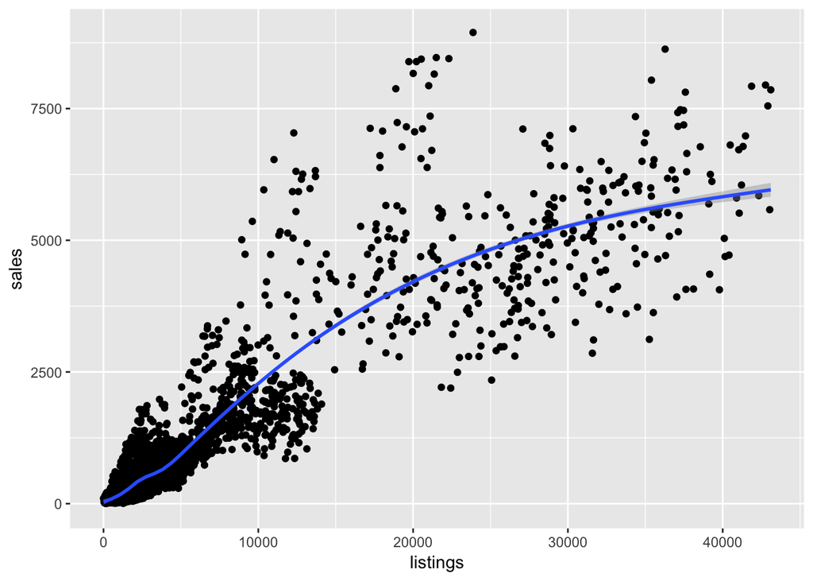

```r
ggplot(data = txhousing_listings_ascending, mapping = aes(x = listings, y = sales)) +
geom_point() +
geom_smooth()
```

## 5.What proportion of sales is missing for each city?

```r
#filter_missing_sales <- txhousing %>%
#                      group_by(city) %>%
#                        filter(is.na(sales))
#filter_missing_sales


txhousing_with_missingsale_info <- txhousing %>%
                                   mutate(missing_sale = is.na(sales)) %>%
                                  group_by(city) %>%
                                  summarise(
                                          count_sales = sum(sales, na.rm = TRUE),
                                          count_missing_sales = sum(missing_sale),
                                          prop_missing_sales = mean(missing_sale, na.rm = TRUE)
                                          )
txhousing_with_missingsale_info
```

```
## # A tibble: 46 x 4
##                     city count_sales count_missing_sales
##                    <chr>       <dbl>               <int>
##  1               Abilene       28141                   0
##  2              Amarillo       44628                   0
##  3             Arlington       79285                   0
##  4                Austin      373381                   0
##  5              Bay Area       93989                   0
##  6              Beaumont       33110                   0
##  7       Brazoria County       16302                  14
##  8           Brownsville       12121                   2
##  9 Bryan-College Station       34921                   0
## 10         Collin County      202892                   0
## # ... with 36 more rows, and 1 more variables: prop_missing_sales <dbl>
```

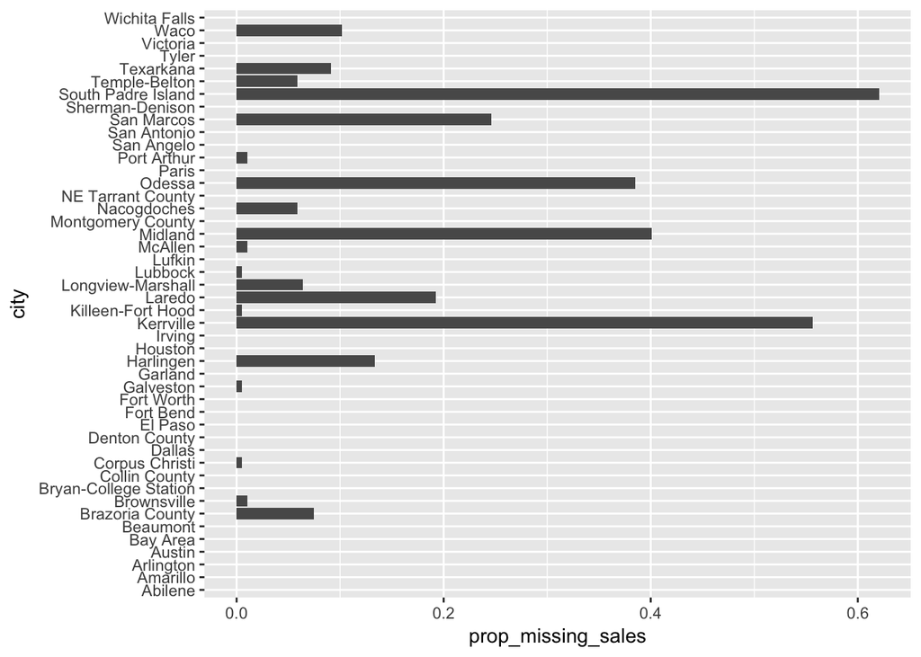

```r
ggplot(data = txhousing_with_missingsale_info, mapping = aes(x = city, y = prop_missing_sales)) +
  geom_col() +
  coord_flip()
```

## 6.Looking at only the cities and months with greater than 500 sales:

### Are the distributions of the median sales price (column name median), when grouped by city, different? The same? Show your work.

```r
#The distribution of the median sales price is different for every city as shown in facet_wrap graph below. However there is a basic trend in the median sales price for almost all cities; the median sales price has climbed up from year 2015 through 2015.


sales_gt500_cities <- txhousing %>%
                      filter(sales > 500) %>%
                      group_by(city) %>%
                      arrange(city)
sales_gt500_cities
```

```
## # A tibble: 1,883 x 9
## # Groups:   city [14]
##         city  year month sales   volume median listings inventory     date
##        <chr> <int> <int> <dbl>    <dbl>  <dbl>    <dbl>     <dbl>    <dbl>
##  1 Arlington  2000     8   507 60875199 103400     1417       3.5 2000.583
##  2 Arlington  2001     5   536 69878959 114400     1592       3.7 2001.333
##  3 Arlington  2001     6   534 67744182 108500     1627       3.8 2001.417
##  4 Arlington  2001     8   505 65080743 113600     1616       3.7 2001.583
##  5 Arlington  2002     5   503 67240236 116100     1741       3.9 2002.333
##  6 Arlington  2002     7   509 66954143 119100     1925       4.4 2002.500
##  7 Arlington  2003     5   502 67131982 118000     2544       5.9 2003.333
##  8 Arlington  2003     7   524 73194692 123500     2799       6.5 2003.500
##  9 Arlington  2003     8   531 72397143 123900     2801       6.4 2003.583
## 10 Arlington  2004     5   527 72401436 118300     2922       6.5 2004.333
## # ... with 1,873 more rows
```

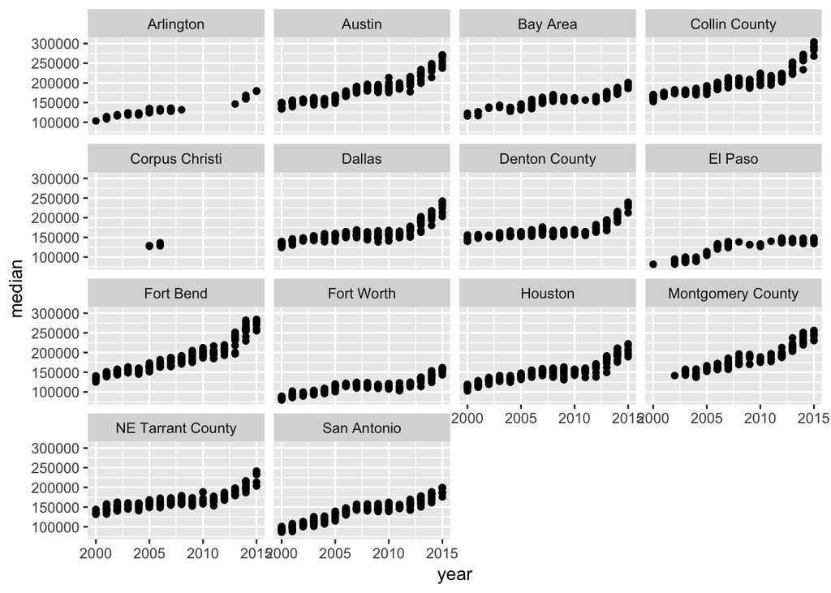

```r
ggplot(data = sales_gt500_cities) +
  geom_point(mapping = aes(x = year, y = median)) +
  facet_wrap(~city)
```

```r
#ggplot(data = sales_gt500_cities, mapping = aes(x = year, y = median)) +
# geom_bar(stat = 'identity') +
#  facet_wrap(~city)
```

### Any cities that stand out that you’d want to investigate further?

```r
#1. City of corpus christi stands out. Not much datapoints available for its graph, which means its number of home sales was much les compared to other cities. Median home price trend for Corpus Christi cannot be fugured out from this chart. It might be worthwhile to separate redraw the graph for corpus christi with all sales included.

#2. City of El Paso stands out, its median sales price over the years seemed to grow during the initial years then flatten out gradually. It needs to be investigated further.
```

### Why might we want to filter out all cities and months with sales less than 500?

```r
#With all sales included in the graph, the graph would become too much cluttered with data points. Filtering out all cities and month with sales less than 500, helps us better understand the trend of the median sale price for each city.
```